# Probability and Statistics I

Lectures 3–6: Measures of Location, Expectation, Moments & MGF

Ms. Beryl Ang’iro

2026-06-02

# 1 Lecture 3: Measures of Location

## 1.1 Quantiles

The $p^{th}$ **quantile** of a random variable $X$, denoted $\xi_p$, is the value such that:

$$\Pr(X \leq \xi_p) \geq p \quad
\text{and} \quad \Pr(X \geq \xi_p) \geq 1 - p$$

In particular, the **median** is the $0.5^{th}$ quantile, denoted $\xi_{0.5}$.

### 1.1.1 Percentiles

Let $0 < p < 1$. The $100p^{th}$ percentile (quantile of order $p$) of the distribution of $X$ is a value $\xi_p$ such that:

$$\Pr(X \leq \xi_p) \geq p \quad
\text{and} \quad \Pr(X \geq \xi_p) \geq 1 - p$$

## 1.2 Median

The median lies halfway through the distribution, splitting the area under the curve into two equal halves.

**Continuous Random Variable:** If $X$ is continuous with pdf $f(x)$ on $(-\infty, \infty)$, the median $M$ satisfies:

$$\int_{-\infty}^{M} f(x)\,dx =
\int_{M}^{\infty} f(x)\,dx = \frac{1}{2}$$

or equivalently $F(M) = \frac{1}{2}$, where $F(x)$ is the CDF.

**Discrete Random Variable:** If $X$ is discrete with PMF $p_X(x)$ and values $x_1, x_2, \ldots, x_n$, the median $M$ satisfies:

$$\sum_{x=x_1}^{M} p_X(x) \geq \frac{1}{2}
\quad \text{and} \quad \sum_{x=M}^{x_n} p_X(x) \geq
\frac{1}{2}$$

### 1.2.1 Example 1: Median and 25th Percentile

Find the median and 25th percentile of:

$$f(x) = \begin{cases} 3(1-x)^2, & 0
< x < 1 \\ 0, & \text{elsewhere} \end{cases}$$

**Solution — Median:**

Let the median be $M$. Setting $\int_0^M 3(1-x)^2\,dx = \frac{1}{2}$ and substituting $z = 1-x$:

$$-(1-M)^3 + 1 = \frac{1}{2} \implies
(1-M)^3 = \frac{1}{2}$$

$$\boxed{M = 1 -
\sqrt[3]{\frac{1}{2}}}$$

**Solution — 25th Percentile:**

Let $P$ be the 25th percentile. Setting $\int_0^P 3(1-x)^2\,dx = \frac{1}{4}$:

$$(1-P)^3 = \frac{3}{4} \implies \boxed{P
= 1 - \sqrt[3]{\frac{3}{4}}}$$

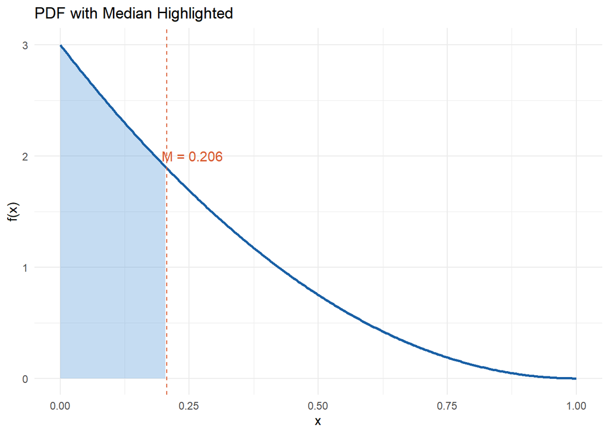

PDF f(x) = 3(1-x)^2 with median shaded

```r
x <- seq(0, 1, length.out = 300)
fx <- 3 * (1 - x)^2
M <- 1 - (1/2)^(1/3)

df <- data.frame(x = x, fx = fx)
df_shade <- df[df$x <= M, ]

ggplot(df, aes(x, fx)) +
  geom_area(data = df_shade, aes(x, fx), fill = "#3B8BD4", alpha = 0.3) +
  geom_line(linewidth = 1, color = "#185FA5") +
  geom_vline(xintercept = M, linetype = "dashed", color = "#D85A30") +
  annotate("text", x = M + 0.05, y = 2, label = paste0("M = ", round(M, 3)),
           color = "#D85A30", size = 4) +
  labs(title = "PDF with Median Highlighted",
       x = "x", y = "f(x)") +
  theme_minimal()
```

### 1.2.2 Example 2: Median of a Discrete Distribution

Given $p = \frac{1}{4}$, find the median of:

$$P_X(x) = \begin{cases} p(1-p)^x, & x
= 0, 1, 2, \ldots \\ 0, & \text{elsewhere} \end{cases}$$

**Solution:**

```r
p <- 1/4
x_vals <- 0:6
pmf <- p * (1 - p)^x_vals
cdf <- cumsum(pmf)

results <- data.frame(x = x_vals, PMF = round(pmf, 4), CDF = round(cdf, 4))
knitr::kable(results, caption = "PMF and CDF for Example 2")
```

PMF and CDF for Example 2

| x | PMF | CDF |
| --- | --- | --- |
| 0 | 0.2500 | 0.2500 |
| 1 | 0.1875 | 0.4375 |
| 2 | 0.1406 | 0.5781 |
| 3 | 0.1055 | 0.6836 |
| 4 | 0.0791 | 0.7627 |
| 5 | 0.0593 | 0.8220 |
| 6 | 0.0445 | 0.8665 |

From the CDF: $F(2) = 0.5781 \geq 0.5$, so the **median is $M = 2$**.

### 1.2.3 Example 3: Finding k, Median, and IQR

$$f(x) = \begin{cases} \frac{k}{\sqrt{x}},
& 1 \leq x \leq 9 \\ 0, & \text{otherwise}
\end{cases}$$

**(i) Finding $k$:**

$$\int_1^9 \frac{k}{\sqrt{x}}\,dx = k[\ln
x]_1^9 = k\ln 9 = 1 \implies k = \frac{1}{\ln 9} \approx
0.4551$$

**(ii) Median:**

The CDF is $F(x) = \frac{\ln x}{\ln 9}$. Setting $F(m) = \frac{1}{2}$:

$$\frac{\ln m}{\ln 9} = \frac{1}{2}
\implies m = 9^{1/2} = 3$$

**(iii) Interquartile Range:**

$$Q_1: F(q_1) = \frac{1}{4} \implies q_1 =
9^{1/4} \approx 1.732$$

$$Q_3: F(q_3) = \frac{3}{4} \implies q_3 =
9^{3/4} \approx 5.196$$

$$\text{IQR} = q_3 - q_1 \approx 5.196 -
1.732 = 3.464$$

```r
k <- 1 / log(9)
q1 <- 9^(1/4); q3 <- 9^(3/4); iqr <- q3 - q1
cat(sprintf("k = %.4f\nMedian = 3\nQ1 = %.3f, Q3 = %.3f\nIQR = %.3f\n",
            k, q1, q3, iqr))
```

```
## k = 0.4551
## Median = 3
## Q1 = 1.732, Q3 = 5.196
## IQR = 3.464
```

## 1.3 Mode

**Definition:** The mode of a distribution is the value $x$ that maximises the PDF or PMF.

For a continuous random variable, differentiate the PDF:

- Set $f'(x) = 0$
- If $f''(x) < 0$ at $x = x_1$ $\Rightarrow$ local maximum (mode)
- Check higher derivatives if needed

### 1.3.1 Example 4: Mode of a Discrete Distribution

$$P_X(x) = \begin{cases}
\left(\frac{1}{2}\right)^x, & x = 1, 2, 3, \ldots \\ 0, &
\text{otherwise} \end{cases}$$

By observation, the maximum probability occurs at $x = 1$, so **Mode = 1**.

### 1.3.2 Example 5: Mode of a Continuous Distribution

$$f(x) = \begin{cases} \frac{1}{2}x^2
e^{-x}, & 0 < x < \infty \\ 0, & \text{otherwise}
\end{cases}$$

**Solution:**

$$f'(x) = \frac{1}{2}e^{-x}(2x - x^2)
= 0 \implies x = 2$$

$$f''(2) = -0.1353 < 0 \implies
\textbf{Mode} = 2$$

### 1.3.3 Example 6: Mode of $f(x) = 12x^2(1-x)$

$$f(x) = \begin{cases} 12x^2(1-x), & 0
< x < 1 \\ 0, & \text{otherwise} \end{cases}$$

$$f'(x) = 24x - 36x^2 = 12x(2 - 3x) =
0 \implies x = 0 \text{ or } x = \frac{2}{3}$$

$f''(2/3) < 0$, so **Mode = $\frac{2}{3}$**.

### 1.3.4 Example 7: Piecewise PDF — CDF, Median, and Mode

$$f(x) = \begin{cases} cx, & 0 \leq x
\leq 1 \\ c(2-x), & 1 \leq x \leq 2 \\ 0, & \text{otherwise}
\end{cases}$$

**Step 1: Find $c$.**

$$\int_0^1 cx\,dx + \int_1^2 c(2-x)\,dx =
\frac{c}{2} + \frac{c}{2} = 1 \implies c = 1$$

**Step 2: CDF.**

$$F(x) = \begin{cases} 0, & x < 0
\\ \dfrac{x^2}{2}, & 0 \leq x \leq 1 \\[6pt] 2x - \dfrac{x^2}{2} -
1, & 1 \leq x \leq 2 \\ 1, & x \geq 2 \end{cases}$$

**Median:** $F(1) = \frac{1}{2}$, so $m = 1$.

**Mode:** $f(x) = x$ increases on $[0,1]$ and $f(x) = 2-x$ decreases on $[1,2]$, so maximum is at $x = 1$. **Mode = 1**.

**Exercise:** For $f(x) = \frac{3}{64}x^2(4-x)$, $0 \leq x \leq 4$, determine the mode.

# 2 Lecture 4: Expectation of a Random Variable

## 2.1 Definition

**Expectation** gives the average (mean) value of a random variable.

- **Discrete:** $E(X) = \displaystyle\sum_{i=1}^n x_i P(X = x_i)$
- **Continuous:** $E(X) = \displaystyle\int_{-\infty}^{\infty} x f(x)\,dx$

## 2.2 Examples

### 2.2.1 Example 1: Fair Die

$$E(X) = \sum_{x=1}^{6} x \cdot
\frac{1}{6} = \frac{1+2+3+4+5+6}{6} = \frac{21}{6} = 3.5$$

### 2.2.2 Example 2: Discrete PMF

$$P(X = x) = \frac{x}{21}, \quad x = 1, 2,
3, 4, 5, 6$$

$$E(X) = \sum_{x=1}^{6} x \cdot
\frac{x}{21} = \frac{1^2 + 2^2 + \cdots + 6^2}{21} = \frac{91}{21}
\approx 4.333$$

### 2.2.3 Example 3: Continuous Case

$$f(x) = \frac{1}{9}(3-x)(1+x), \quad 0
\leq x \leq 3$$

$$E(X) = \frac{1}{9}\int_0^3
x(3-x)(1+x)\,dx = \frac{1}{9}\int_0^3 (3x + 3x^2 - x^3 - x^4)\,dx =
\frac{5}{4} = 1.25$$

```r
integrand <- function(x) x * (1/9) * (3 - x) * (1 + x)
result <- integrate(integrand, 0, 3)
cat("E(X) =", result$value)
```

```
## E(X) = 1.25
```

## 2.3 Properties of Expectation

Let $g(X) = aX + b$ with constants $a, b, c$:

1. $E(c) = c$
2. $E[aX + b] = aE(X) + b$
3. $E[ag(X) \pm bh(X)] = aE[g(X)] \pm bE[h(X)]$

**Proof of (2):**

$$E[aX + b] = \int_{-\infty}^{\infty}(aX +
b)f(x)\,dx = a\int_{-\infty}^{\infty}xf(x)\,dx +
b\int_{-\infty}^{\infty}f(x)\,dx = aE(X) + b$$

### 2.3.1 Example 4: Expectation of Functions

$$P(X = x) = \frac{x}{10}, \quad x = 1, 2,
3, 4$$

Compute $E[5X^3 - 2X^2]$:

$$E[5X^3 - 2X^2] = 5E(X^3) -
2E(X^2)$$

```r
x <- 1:4; p <- x / 10
E_X2 <- sum(x^2 * p)
E_X3 <- sum(x^3 * p)
result <- 5 * E_X3 - 2 * E_X2
cat(sprintf("E(X^2) = %.1f\nE(X^3) = %.1f\nE[5X^3 - 2X^2] = %.1f\n",
            E_X2, E_X3, result))
```

```
## E(X^2) = 10.0
## E(X^3) = 35.4
## E[5X^3 - 2X^2] = 157.0
```

## 2.4 Variance of a Random Variable

$$\text{Var}(X) = E\left[(X -
E(X))^2\right] = E(X^2) - [E(X)]^2$$

**Notation:** Mean $\mu = E(X)$; Variance $\sigma^2 = \text{Var}(X)$; Standard deviation $\sigma = \sqrt{\text{Var}(X)}$.

### 2.4.1 Variance of Linear Functions

$$\text{Var}(aX) =
a^2\text{Var}(X)$$
$$\text{Var}(aX +
b) = a^2\text{Var}(X)$$

**Proof of $\text{Var}(aX + b) = a^2\text{Var}(X)$:**

$$\text{Var}(aX + b) = E[(aX+b)^2] -
[E(aX+b)]^2$$
$$= a^2E(X^2) + 2abE(X)
+ b^2 - [aE(X) + b]^2$$
$$=
a^2\left[E(X^2) - (E(X))^2\right] = a^2\text{Var}(X)$$

### 2.4.2 Example 5: Variance of a Continuous Variable

$$f(x) = \frac{x+3}{18}, \quad -3 \leq x
\leq 3$$

```r
E_X  <- integrate(function(x) x * (x + 3) / 18, -3, 3)$value
E_X2 <- integrate(function(x) x^2 * (x + 3) / 18, -3, 3)$value
VarX <- E_X2 - E_X^2
cat(sprintf("E(X) = %.4f\nE(X^2) = %.4f\nVar(X) = %.4f\n", E_X, E_X2, VarX))
```

```
## E(X) = 1.0000
## E(X^2) = 3.0000
## Var(X) = 2.0000
```

### 2.4.3 Example 6: Piecewise PDF

$$f(x) = \begin{cases} kx, & 0 \leq x
\leq 1 \\ k, & 1 \leq x \leq 3 \\ k(4-x), & 3 \leq x \leq 4 \\
0, & \text{otherwise} \end{cases}$$

**Finding $k$:**

$$k\int_0^1 x\,dx + k\int_1^3 dx +
k\int_3^4(4-x)\,dx = k\left(\frac{1}{2} + 2 + \frac{1}{2}\right) = 3k =
1 \implies k = \frac{1}{3}$$

**Finding $E(X)$:**

$$E(X) = \frac{1}{3}\int_0^1 x^2\,dx +
\frac{1}{3}\int_1^3 x\,dx + \frac{1}{3}\int_3^4 x(4-x)\,dx =
2$$

### 2.4.4 Example 7: Piecewise PDF with Quantile

$$f(x) = \begin{cases} \frac{c}{3}x, &
0 \leq x \leq 3 \\ c, & 3 \leq x \leq 4 \\ 0, & \text{otherwise}
\end{cases}$$

**Finding $c$:** $\frac{3}{2}c + c = \frac{5}{2}c = 1 \implies c = \frac{2}{5}$

**$E(X) = \frac{13}{5} = 2.6$**

**Finding $a$ such that $P(X \geq a) = 0.85$:**

Since $P(0 \leq X \leq 3) = 0.40$, the value $a$ lies in $[3, 4]$:

$$\int_a^4 \frac{2}{5}\,dx = 0.85 - P(X
> 4) \implies \frac{2}{5}(4 - a) = 0.85 - 0.40 = 0.45 \implies a =
5.125$$

> **Note:** The solution in the lecture notes sets $\int_3^a \frac{2}{5}dx = 0.85 - P(0 \le X \le 3)$, giving $a = 5.125$.

### 2.4.5 Example 8: Cell Battery Lifetime

$$f(x) = \begin{cases} \frac{3}{4}\left[1
- (x-2)^2\right], & 1 \leq x \leq 3 \\ 0, & \text{otherwise}
\end{cases}$$

**(i) $E(X)$:**

$$E(X) = \frac{3}{4}\int_1^3 x\left[1 -
(x-2)^2\right]dx = 2$$

**(ii) Probability radio works for at least 22 hours (two independent cells, each $\geq 2.2$ tens of hours):**

$$P(X \geq 2.2) =
\frac{3}{4}\int_{2.2}^{3}\left[1 - (x-2)^2\right]dx \approx
0.352$$

$$P(\text{both cells}) = (0.352)^2 \approx
0.1239$$

```r
f8 <- function(x) (3/4) * (1 - (x - 2)^2)
p_22 <- integrate(f8, 2.2, 3)$value
cat(sprintf("P(X >= 2.2) = %.4f\nP(both cells) = %.4f\n", p_22, p_22^2))
```

```
## P(X >= 2.2) = 0.3520
## P(both cells) = 0.1239
```

### 2.4.6 Example 9: Electric Bulb Lifetime

$$f(x) = \begin{cases}
\frac{6}{125}x(5-x), & 0 \leq x \leq 5 \\ 0, & \text{otherwise}
\end{cases}$$

```r
f9 <- function(x) (6/125) * x * (5 - x)

# Probability neither bulb fails in the first year
p_fail1 <- integrate(f9, 0, 1)$value
p_surv1 <- 1 - p_fail1
p_neither <- p_surv1^2

# Probability exactly one bulb fails within 2 years
p_fail2 <- integrate(f9, 0, 2)$value
p_surv2 <- 1 - p_fail2
p_exactly_one <- 2 * p_fail2 * p_surv2

cat(sprintf("P(fail in year 1) = %.4f\nP(neither fails in year 1) = %.4f\n", p_fail1, p_neither))
```

```
## P(fail in year 1) = 0.1040
## P(neither fails in year 1) = 0.8028
```

```r
cat(sprintf("P(fail within 2 years) = %.4f\nP(exactly one fails in 2 years) = %.4f\n", p_fail2, p_exactly_one))
```

```
## P(fail within 2 years) = 0.3520
## P(exactly one fails in 2 years) = 0.4562
```

**Exercise:** Two dice are tossed. Let $Y = |X_1 - X_2|$. Compute $\text{Var}(Y)$.

# 3 Lecture 5: Moments of a Random Variable

## 3.1 Definition

Moments are expectations of powers of a random variable and characterise properties of the distribution.

## 3.2 Raw Moments (About the Origin)

The $r^{th}$ **raw moment** of $X$, denoted $\mu'_r$, is:

$$\mu'_r = E(X^r), \quad r = 1, 2,
\ldots$$

## 3.3 Central Moments (About the Mean)

If $a = E(X) = \mu$, the $r^{th}$ **central moment** is:

$$\mu_r = E\left[(X -
\mu)^r\right]$$

### 3.3.1 Formulas

**Discrete:**

$$\mu'_r = \sum_x x^r P(X = x), \qquad
\mu_r = \sum_x (x - \mu)^r P(X = x)$$

**Continuous:**

$$\mu'_r = \int_{-\infty}^{\infty} x^r
f(x)\,dx, \qquad \mu_r = \int_{-\infty}^{\infty} (x - \mu)^r
f(x)\,dx$$

## 3.4 Remarks

| Moment | Result |
| --- | --- |
| $\mu'_1 = E(X^1)$ | Mean of $X$ |
| $\mu_1 = E[(X-\mu)^1]$ | Always $= 0$ |
| $\mu_2 = E[(X-\mu)^2]$ | Variance of $X$ |

## 3.5 Relationships Between Raw and Central Moments

**Second central moment:**

$$\mu_2 = \mu'_2 -
(\mu'_1)^2$$

**Third central moment:**

$$\mu_3 = \mu'_3 -
3\mu'_1\mu'_2 + 2(\mu'_1)^3$$

**Fourth central moment (exercise):**

$$\mu_4 = \mu'_4 -
4\mu'_3\mu'_1 + 6\mu'_2(\mu'_1)^2 -
3(\mu'_1)^4$$

## 3.6 Factorial Moments

The $r^{th}$ **factorial moment** of $X$ is:

$$\mu_{[r]} =
E[X(X-1)(X-2)\cdots(X-r+1)]$$

The first factorial moment is always the mean: $\mu_{[1]} = E(X)$.

### 3.6.1 Example 13: Factorial Moments of a Fair Die

```r
x <- 1:6; p <- rep(1/6, 6)

mu1 <- sum(x * p)
mu2 <- sum(x * (x - 1) * p)
mu3 <- sum(x * (x - 1) * (x - 2) * p)

df_fact <- data.frame(
  x = x,
  Prob = p,
  `x(x-1)` = x * (x - 1),
  `x(x-1)(x-2)` = x * (x - 1) * (x - 2),
  check.names = FALSE
)
knitr::kable(df_fact, caption = "Factorial moment calculations for a fair die")
```

Factorial moment calculations for a fair die

| x | Prob | x(x-1) | x(x-1)(x-2) |
| --- | --- | --- | --- |
| 1 | 0.1666667 | 0 | 0 |
| 2 | 0.1666667 | 2 | 0 |
| 3 | 0.1666667 | 6 | 6 |
| 4 | 0.1666667 | 12 | 24 |
| 5 | 0.1666667 | 20 | 60 |
| 6 | 0.1666667 | 30 | 120 |

```r
cat(sprintf("\n1st Factorial Moment E(X)         = %.4f\n", mu1))
```

```
##
## 1st Factorial Moment E(X)         = 3.5000
```

```r
cat(sprintf("2nd Factorial Moment E[X(X-1)]     = %.4f\n", mu2))
```

```
## 2nd Factorial Moment E[X(X-1)]     = 11.6667
```

```r
cat(sprintf("3rd Factorial Moment E[X(X-1)(X-2)]= %.4f\n", mu3))
```

```
## 3rd Factorial Moment E[X(X-1)(X-2)]= 35.0000
```

# 4 Lecture 6: Moment Generating Function (MGF)

## 4.1 Introduction

Computing all moments directly can be tedious. The **moment generating function (MGF)** generates all moments from a single function. It is unique to each distribution, allowing identification of the distribution from its MGF.

## 4.2 Definition

Let $X$ be a random variable. The MGF, denoted $M_X(t)$, is:

$$M_X(t) = E\left[e^{tX}\right], \quad -h
< t < h, \quad h > 0$$

**Discrete:**

$$M_X(t) = \sum_{\text{all } x} e^{tx} P(X
= x)$$

**Continuous:**

$$M_X(t) = \int_{-\infty}^{\infty} e^{tx}
f(x)\,dx$$

## 4.3 Deriving Moments from the MGF

Using the Taylor expansion $e^{tx} = 1 + tx + \frac{t^2 x^2}{2!} + \frac{t^3 x^3}{3!} + \cdots$ and differentiating $M_X(t)$ with respect to $t$:

$$M'_X(t)\Big|_{t=0} = E(X) =
\mu'_1$$

$$M''_X(t)\Big|_{t=0} = E(X^2) =
\mu'_2$$

**General result:** The $r^{th}$ raw moment is obtained by differentiating the MGF $r$ times and setting $t = 0$:

$$\mu'_r = E(X^r) =
M_X^{(r)}(t)\Big|_{t=0}$$

## 4.4 Example: Exponential Distribution

$$f(x) = \begin{cases} \lambda e^{-\lambda
x}, & x > 0 \\ 0, & \text{elsewhere} \end{cases}$$

### 4.4.1 (a) Finding the MGF

$$M_X(t) = \int_0^{\infty} e^{tx} \cdot
\lambda e^{-\lambda x}\,dx = \lambda \int_0^{\infty} e^{-(\lambda -
t)x}\,dx = \frac{\lambda}{\lambda - t}, \quad t <
\lambda$$

### 4.4.2 (b) Mean and Variance from the MGF

$$M'_X(t) = \lambda(\lambda -
t)^{-2}$$

$$E(X) = M'_X(0) =
\frac{\lambda}{\lambda^2} = \frac{1}{\lambda}$$

$$M''_X(t) = 2\lambda(\lambda -
t)^{-3}$$

$$E(X^2) = M''_X(0) =
\frac{2}{\lambda^2}$$

$$\text{Var}(X) = E(X^2) - [E(X)]^2 =
\frac{2}{\lambda^2} - \frac{1}{\lambda^2} =
\frac{1}{\lambda^2}$$

### 4.4.3 (c) Verification (Direct Calculation)

```r
lambda_vals <- c(0.5, 1, 2, 5)

results <- lapply(lambda_vals, function(lam) {
  # Direct integration
  EX  <- integrate(function(x) x * lam * exp(-lam * x), 0, Inf)$value
  EX2 <- integrate(function(x) x^2 * lam * exp(-lam * x), 0, Inf)$value
  data.frame(
    Lambda    = lam,
    `E(X) formula` = round(1 / lam, 4),
    `E(X) direct`  = round(EX, 4),
    `Var(X) formula` = round(1 / lam^2, 4),
    `Var(X) direct`  = round(EX2 - EX^2, 4),
    check.names = FALSE
  )
})

knitr::kable(do.call(rbind, results),
             caption = "Verification: MGF formula vs direct integration for Exponential distribution")
```

Verification: MGF formula vs direct integration for Exponential distribution

| Lambda | E(X) formula | E(X) direct | Var(X) formula | Var(X) direct |
| --- | --- | --- | --- | --- |
| 0.5 | 2.0 | 2.0 | 4.00 | 4.00 |
| 1.0 | 1.0 | 1.0 | 1.00 | 1.00 |
| 2.0 | 0.5 | 0.5 | 0.25 | 0.25 |
| 5.0 | 0.2 | 0.2 | 0.04 | 0.04 |

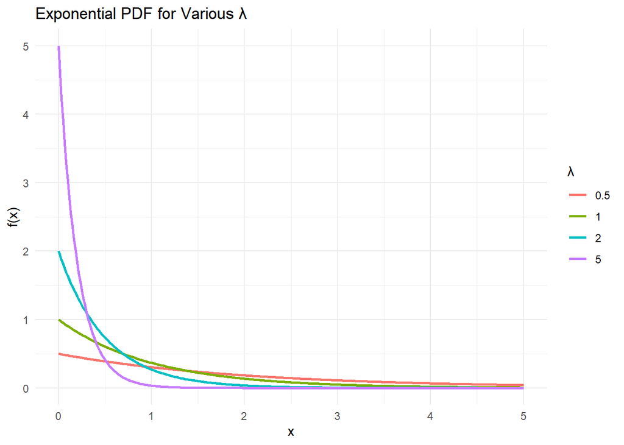

Exponential PDF for various lambda values

```r
x_seq <- seq(0, 5, length.out = 300)
df_exp <- do.call(rbind, lapply(lambda_vals, function(lam) {
  data.frame(x = x_seq, fx = lam * exp(-lam * x_seq), lambda = factor(lam))
}))

ggplot(df_exp, aes(x, fx, color = lambda)) +
  geom_line(linewidth = 1) +
  labs(title = "Exponential PDF for Various λ",
       x = "x", y = "f(x)", color = "λ") +
  theme_minimal()
```

## 4.5 Summary Table

| Concept | Formula |
| --- | --- |
| Raw moment | $\mu'_r = E(X^r)$ |
| Central moment | $\mu_r = E[(X - \mu)^r]$ |
| MGF | $M_X(t) = E[e^{tX}]$ |
| Mean from MGF | $E(X) = M'_X(0)$ |
| Variance from MGF | $\text{Var}(X) = M''_X(0) - [M'_X(0)]^2$ |
| $\mu_2 = \sigma^2$ | $\mu'_2 - (\mu'_1)^2$ |
| $\mu_3$ | $\mu'_3 - 3\mu'_1\mu'_2 + 2(\mu'_1)^3$ |

*End of Lectures 3–6 | Probability and Statistics I*